# Demo of the summary statistics

Richel Bilderbeek

2016-05-18

There are multiple phylogeny summary statistics:

- Femke and Jolien summary statistic
- Gamma statistic
- Colless statistic

First it is shown how a parameter file is built up, then the individual summary statistics are shown

## Parameter file build-up

For this vignette, we need these libraries:

```r
library(ape)
library(Cer2016)
```

First we obtain the full path of a parameter file:

```r
filename <- find_path("toy_example_1.RDa")
print(filename)
```

```
## [1] "/home/p230198/GitHubs/Cer2016/inst/extdata/toy_example_1.RDa"
```

This path will be different: Windows users will have a path starting with `C:/` or `D:/` or higher. GNU/Linux users will have a UNIX path.

The function `read_file` reads the file (it also checks if the file does indeed exist):

```r
file <- read_file(filename)
```

`file`, which is a file, has a (hopefully) convenient structure. This structure can be observed using `names`:

```r
print(names(file))
```

```
## [1] "parameters"                  "pbd_output"
## [3] "species_trees_with_outgroup" "alignments"
## [5] "posteriors"
```

The (unsampled) (original) incipient species tree is in `file$pbd_output`, let’s see what’s there:

```r
print(names(file$pbd_output))
```

```
##  [1] "tree"           "stree_random"   "stree_oldest"   "stree_youngest"
##  [5] "L"              "sL_random"      "sL_oldest"      "sL_youngest"
##  [9] "igtree.extinct" "igtree.extant"  "recontree"      "reconL"
## [13] "L0"
```

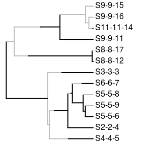

```r
incipient_species_tree <- file$pbd_output$igtree.extant
colors <- setNames(c("gray", "black"), c("i","g"))
phytools::plotSimmap(
  incipient_species_tree,
  colors = colors
)
```

I chose to plot the incipient species tree for extant species, thus `igtree.extant`. Because an incipient species trees has states on the edges (`good` and `incipient`), it is not a phylogeny of class `phylo` but has additional data as well.

## Gamma statistic

The gamma statistic was introduced by Pybus and Harvey (2000).

- `gamma < 0`: a tippy tree
- `gamma > 0`: a stemmy tree

The incipient species tree looks like this:

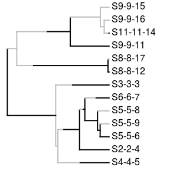

```r
colors <- setNames(c("gray","black"), c("i","g"))
testit::assert(length(read_file(filename)$pbd_output$igtree.extant$tip.label) > 0)
phytools::plotSimmap(
  file$pbd_output$igtree.extant,
  colors = colors
)
```

I will use a sampled species tree as my true tree:

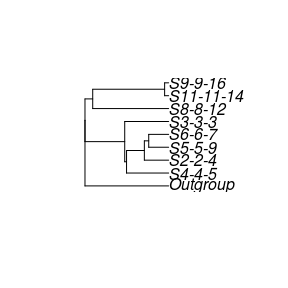

```r
true_tree <- file$species_trees_with_outgroup[[1]][[1]]
plot(true_tree)
```

Note that `[[1]][[1]]`: it allows for multiple sampled species trees for more complex parameter files, but here it just looks ugly.

From that true tree, I measure the gamma statistic:

```r
true_gamma <- gammaStat(true_tree)
print(true_gamma)
```

```
## [1] -0.8205514
```

```r
if (true_gamma < 0) {
  print("tippy tree")
} else {
  print("stemmy tree")
}
```

```
## [1] "tippy tree"
```

The question is: how is the distribution of that statistic in the posterior?

This toy example has only one posterior file:

```r
posterior_filename <- find_path("toy_example_1_1_1_1.trees")
```

Extracting the trees from that posterior:

```r
posterior_trees <- rBEAST::beast2out.read.trees(posterior_filename)
n_trees <- length(posterior_trees)
print(paste0("There are ", n_trees))
```

```
## [1] "There are 10"
```

For giggles, let’s plot all 10 posterior trees:

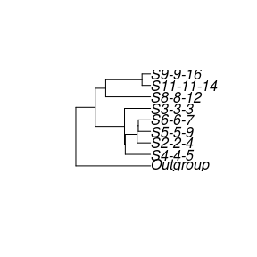

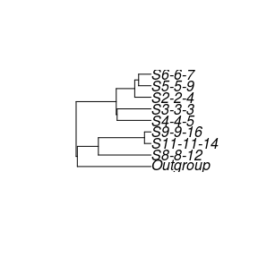

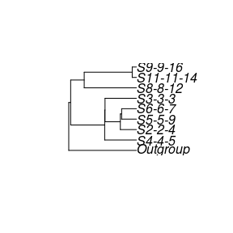

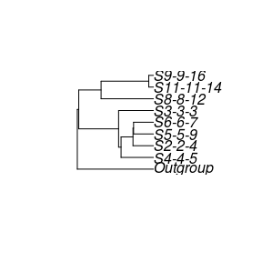

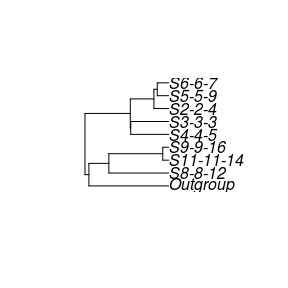

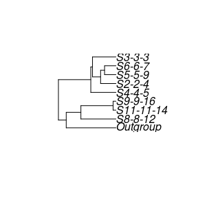

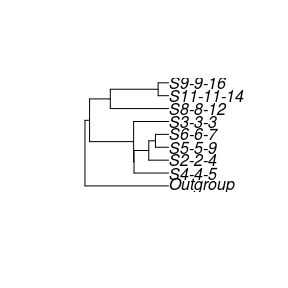

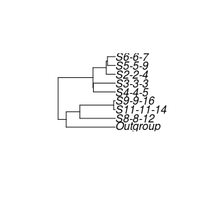

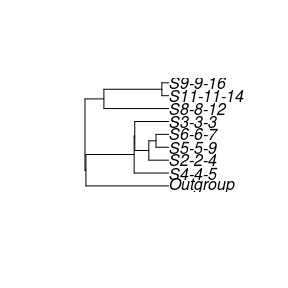

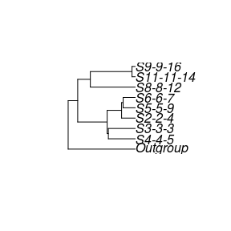

```r
for (i in seq(1:n_trees)) {
  plot(posterior_trees[[i]])
}
```

From those posterior trees, we collect the gamma statistic:

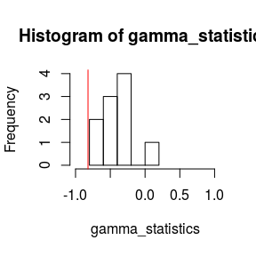

```r
gamma_statistics <- rep(0, times = n_trees)
for (i in seq(1:n_trees)) {
  gamma_statistics[i] <- gammaStat(posterior_trees[[i]])
}
hist(gamma_statistics, xlim = c(-1,1))
abline(v = true_gamma, col = "red")
```

## Colless statistic [DOES NOT WORK]

The Colless statistic was introduced by Colless (1982).

First, we read a parameter file:

```
library(ape)
library(Cer2016)
library(phytools)
library(apTreeshape) # For colless
filename <- find_path("toy_example_1.RDa")
file <- read_file(filename)
```

I will use that tree as my true tree (sorry for all those square brackets):

```
true_tree <- file$species_trees_with_outgroup[[1]][[1]]
plot(true_tree)
```

This does not work:

```
true_colless  <- colless(true_tree)
print(true_colless)
```

It does not work as `colless` needs a `apTreeShape` (from the `apTreeShape` package). Also their PPtree example is unclear to me:

```
library(PPtree)
data(iris)
n <- nrow(iris)
tot <- c(1:n)
n.train <- round(n*0.9)
train <- sample(tot, n.train)
test <- tot[-train]

Tree.result <- PDA.Tree(iris[train,5], iris[train,1:4])
Tree.result
plot(Tree.result$Tree.Struct)
```

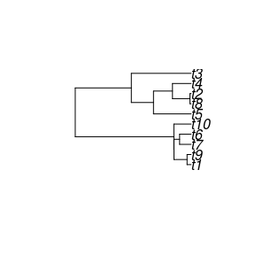

```r
library(ape)
phylogeny <- rcoal(10)
plot(phylogeny)
```

The statistic is very in-/sensitive, as when we compare the phylogeny to itself, the values already differ????

```r
measurement_1 <- stats::runif(n = 1, max = sum(phylogeny$edge.length))
measurement_2 <- stats::runif(n = 1, max = sum(phylogeny$edge.length))
print(measurement_1)
```

```
## [1] 1.090055
```

```r
print(measurement_2)
```

```
## [1] 0.8783801
```